# Daily Exercise 11 and 12: Building Linear Regression Models

Author

Genesis Lacy, ESS 330

Part 1: Normality Testing

```r
library(tidyverse)
data("airquality")
str(airquality)
```

```
'data.frame':   153 obs. of  6 variables:
 $ Ozone  : int  41 36 12 18 NA 28 23 19 8 NA ...
 $ Solar.R: int  190 118 149 313 NA NA 299 99 19 194 ...
 $ Wind   : num  7.4 8 12.6 11.5 14.3 14.9 8.6 13.8 20.1 8.6 ...
 $ Temp   : int  67 72 74 62 56 66 65 59 61 69 ...
 $ Month  : int  5 5 5 5 5 5 5 5 5 5 ...
 $ Day    : int  1 2 3 4 5 6 7 8 9 10 ...
```

```r
summary(airquality)
```

```
     Ozone           Solar.R           Wind             Temp
 Min.   :  1.00   Min.   :  7.0   Min.   : 1.700   Min.   :56.00
 1st Qu.: 18.00   1st Qu.:115.8   1st Qu.: 7.400   1st Qu.:72.00
 Median : 31.50   Median :205.0   Median : 9.700   Median :79.00
 Mean   : 42.13   Mean   :185.9   Mean   : 9.958   Mean   :77.88
 3rd Qu.: 63.25   3rd Qu.:258.8   3rd Qu.:11.500   3rd Qu.:85.00
 Max.   :168.00   Max.   :334.0   Max.   :20.700   Max.   :97.00
 NA's   :37       NA's   :7
     Month            Day
 Min.   :5.000   Min.   : 1.0
 1st Qu.:6.000   1st Qu.: 8.0
 Median :7.000   Median :16.0
 Mean   :6.993   Mean   :15.8
 3rd Qu.:8.000   3rd Qu.:23.0
 Max.   :9.000   Max.   :31.0
```

```r
shapiro.test(airquality$Ozone)
```

```
    Shapiro-Wilk normality test

data:  airquality$Ozone
W = 0.87867, p-value = 2.79e-08
```

```r
shapiro.test(airquality$Solar.R)
```

```
    Shapiro-Wilk normality test

data:  airquality$Solar.R
W = 0.94183, p-value = 9.492e-06
```

```r
shapiro.test(airquality$Wind)
```

```
    Shapiro-Wilk normality test

data:  airquality$Wind
W = 0.98575, p-value = 0.1178
```

```r
shapiro.test(airquality$Temp)
```

```
    Shapiro-Wilk normality test

data:  airquality$Temp
W = 0.97617, p-value = 0.009319
```

The purpose of performing these tests is to see if the data we’re using has a normal distribution.

Running the following code to see what our null and alternative hypotheses are:

```r
moments::agostino.test(na.omit(airquality$Ozone))
```

```
    D'Agostino skewness test

data:  na.omit(airquality$Ozone)
skew = 1.2257, z = 4.6564, p-value = 3.219e-06
alternative hypothesis: data have a skewness
```

```r
moments::agostino.test(na.omit(airquality$Solar.R))
```

```
    D'Agostino skewness test

data:  na.omit(airquality$Solar.R)
skew = -0.42363, z = -2.10903, p-value = 0.03494
alternative hypothesis: data have a skewness
```

```r
moments::agostino.test(na.omit(airquality$Wind))
```

```
    D'Agostino skewness test

data:  na.omit(airquality$Wind)
skew = 0.3444, z = 1.7720, p-value = 0.07639
alternative hypothesis: data have a skewness
```

```r
moments::agostino.test(na.omit(airquality$Temp))
```

```
    D'Agostino skewness test

data:  na.omit(airquality$Temp)
skew = -0.37417, z = -1.91727, p-value = 0.0552
alternative hypothesis: data have a skewness
```

large p-value shows normal distrubtion and low value indicates there isnt normal distr

Per the D’Agostino test that was just ran:

- Ozone has a skewness of 1.2257 and there is an alt hypothesis. The p-value indicates that it’s not normally distributed.
- Solar radiation has a skewness of -0.42363 and there is an alt hypothesis. The p-value indicates that it’s not normally distributed.
- Wind has a skewness of 0.3444 and there is an alt hypothesis but this set of our data will have the most normality because the skewness is almost equal to 0.0. The p-value indicates that there might be a more normal distribution.
- Temperature has s skewness of -0.37417 and there is an alt hypothesis. The p-value indicates that there is also a more normal distribution because its value is 0.0552.

Part 2: Data transformation and Feature Engineering

```r
## creating a new column with case_when translating the months in 4 seasons

airquality <- airquality%>%
  mutate(Season = case_when(
    Month %in% c(11, 12, 1) ~ "Winter",
    Month %in% c(2, 3, 4) ~ "Spring",
    Month %in% c(5, 6, 7) ~ "Summer",
    Month %in% c(8, 9, 10) ~ "Fall"
  ))

table(airquality$Season)
```

```
  Fall Summer
    61     92
```

Part 3: Data processing

```r
## making a recipe with the variables
## prep and bake to generate a processed dataset

airquality <- airquality%>%
  mutate(Season = case_when(
    Month %in% c(11, 12, 1) ~ "Winter",
    Month %in% c(2, 3, 4) ~ "Spring",
    Month %in% c(5, 6, 7) ~ "Summer",
    Month %in% c(8, 9, 10) ~ "Fall"
  )) %>%
mutate(Season = factor(Season))

library(recipes)
recipe_airquality <- recipe(Ozone ~ Temp + Solar.R + Wind + Season, data = airquality) %>%
  step_impute_mean(Temp, Solar.R, Wind) %>%
  step_normalize(Temp, Solar.R,Wind) %>%
  step_dummy(Season)


processed_data <- recipe_airquality %>%
  prep() %>%
  bake(new_data = NULL)

head(processed_data)
```

```
# A tibble: 6 × 5
    Temp   Solar.R   Wind Ozone Season_Summer
   <dbl>     <dbl>  <dbl> <int>         <dbl>
1 -1.15   0.0462   -0.726    41             1
2 -0.621 -0.772    -0.556    36             1
3 -0.410 -0.420     0.750    12             1
4 -1.68   1.44      0.438    18             1
5 -2.31   0.000743  1.23     NA             1
6 -1.26   0.000743  1.40     28             1
```

The purpose of normalizing this data is to make is easier to understand which can be difficult to do because the variables in the dataset have different units.

The function that can be used to impute missing values with the mean is step_impute_mean().

It’s necessary to prep and bake the recipe because prepping calculates what needs to be done to the variables and baking the recipe is what will be done to the dataset.

Part 4: Building a Linear Regression Model

```r
lm_model <- lm(Ozone ~ ., data = processed_data)

summary(lm_model)
```

```
Call:
lm(formula = Ozone ~ ., data = processed_data)

Residuals:
    Min      1Q  Median      3Q     Max
-39.595 -14.802  -2.437  10.510  99.531

Coefficients:
              Estimate Std. Error t value Pr(>|t|)
(Intercept)     39.815      2.970  13.405  < 2e-16 ***
Temp            16.376      2.477   6.612 1.38e-09 ***
Solar.R          4.857      2.108   2.304   0.0231 *
Wind           -10.952      2.282  -4.800 4.98e-06 ***
Season_Summer    3.988      4.197   0.950   0.3441
---
Signif. codes:  0 '***' 0.001 '**' 0.01 '*' 0.05 '.' 0.1 ' ' 1

Residual standard error: 21.33 on 111 degrees of freedom
  (37 observations deleted due to missingness)
Multiple R-squared:  0.5964,    Adjusted R-squared:  0.5819
F-statistic: 41.01 on 4 and 111 DF,  p-value: < 2.2e-16
```

Part 5: Model Diagnostics

```r
library(broom)
library(ggpubr)
augmented_data <- augment(lm_model)

dim(augmented_data)
```

```
[1] 116  12
```

```r
dim(processed_data)
```

```
[1] 153   5
```

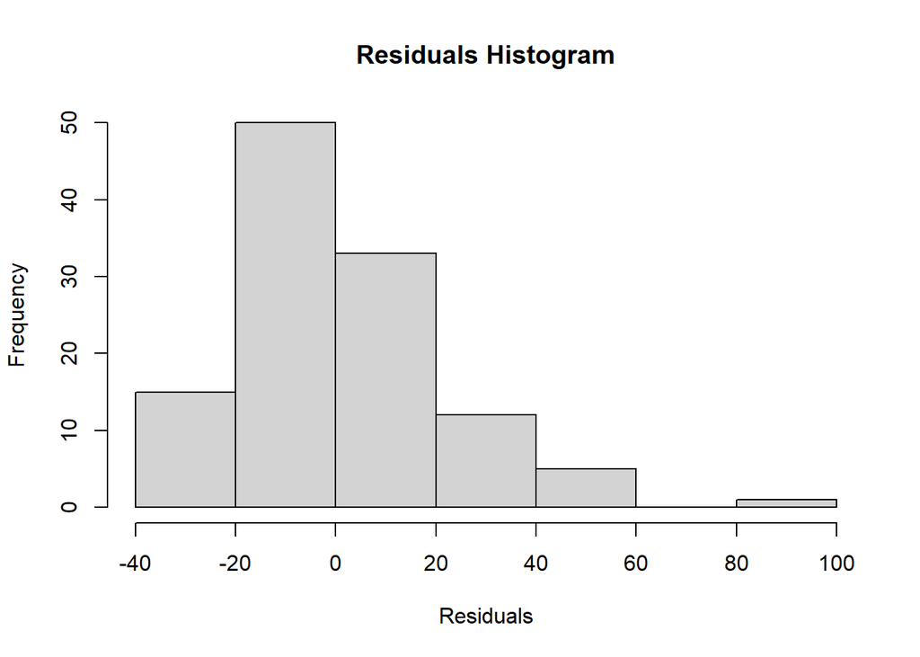

```r
hist(augmented_data$.resid, main = "Residuals Histogram", xlab = "Residuals")
```

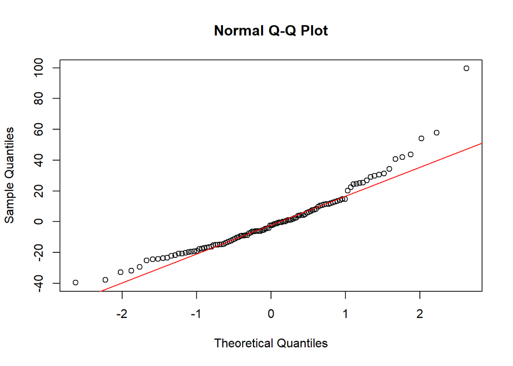

```r
qqnorm(augmented_data$.resid)
qqline(augmented_data$.resid, col = "red")
```

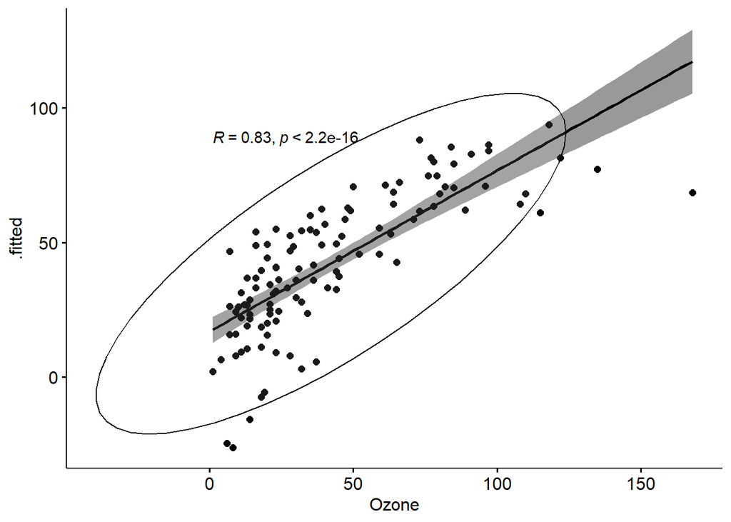

```r
ggscatter(augmented_data, x = "Ozone", y = ".fitted",
          add = "reg.line", conf.int = TRUE,
          cor.coef = TRUE, cor.method = "spearman",
          ellipse = TRUE)
```

How strong of a model do you think this is?

I think this a strong model but I think it’s also important to look at the other variables such as temperature and solar radiation in comparison to each other. This wold be able to tell us more about changes and differences in seasonality.